# filter_by_variant_effect_wecare_only

started: Alexey Larionov, 2016  
last updated: Alexey Larionov, 29Aug2017

# Summary

237,258 -> 17,857 variants

8,936 genes:  
~2 variants (mean) per gene  
~28 inv-aggr-alt-counts (mean) per gene (median = 2, MACs)

### Including Loss of function variants

“splice_acceptor_variant”, “splice_donor_variant”, “stop_gain”, “stop_lost”,  
“start_lost”, “frameshift_variant” : 3,948 variants

### Including dd-missense variants, likely affecting protein function

“deleterious” and “probably_damaging”: 13,752 variants (of 86,342 total missenses)  
add NMD-transcripts ?

### Including ClinSig variants

“likely_pathogenic”, “risk_factor”, “pathogenic”, “association”, “protective”,  
“drug_response”: 1,091 variants

### Excluding ClinSig variants

“benign”, “likely_benign”: 11,709 variants

### NOT excluding multiallelic variaints

394 multiallelic varaints in the selected

## Invert genotypes after filtering

SKAT-style inversion: for variants with **total** AF > 0.5  
The inverted data will be used for exploration in this script and  
for filtering in the next script

## Explore the selected variants

AFs, numbers of variants, inv-aggr-alt-counts (MACs) per gene etc

Input data: 237,258 vars x 478 cases (245 UBC and 233 CBC)  
Output data: 17,857 vars x 478 cases (245 UBC and 233 CBC)

# start_section

```r
# Start time
Sys.time()
```

```
## [1] "2017-08-29 19:10:00 BST"
```

```r
# Clenan-up
rm(list=ls())

# Libraries location
.libPaths("/home/alarionov/R/my_libs_r3.4.1/")

# Base folder
library(knitr)
base_folder="/analysis/mtgroup_share/users/alexey/wecare_only_08.17"
opts_knit$set(root.dir = base_folder)
#setwd(base_folder)

# Load libraries
library(dplyr)
```

```r
library(reshape2) # for melt()
library(ggplot2)
library(VennDiagram)
```

# load_data

```r
#base_folder="/analysis/mtgroup_share/users/alexey/wecare_only_08.17"
load(paste(base_folder, "results", "r06_exclude_eigenvectors_outliers_wecare_only.RData", sep="/"))
```

# check_data

```r
ls()
```

```
## [1] "base_folder"   "exac.df"       "genotypes.mx"  "kgen.df"
## [5] "phenotypes.df" "variants.df"
```

```r
dim(genotypes.mx)
```

```
## [1] 237258    478
```

```r
class(genotypes.mx)
```

```
## [1] "matrix"
```

```r
genotypes.mx[1:5,1:5]
```

```
##              P1_A01 P1_A02 P1_A03 P1_A04 P1_A05
## Var000000001      0      1      0      0      0
## Var000000002      0      0      0      0      0
## Var000000008      0      0     NA      0     NA
## Var000000020      0      0      0      0      0
## Var000000021      0      0      0      0      0
```

```r
dim(phenotypes.df)
```

```
## [1] 478  36
```

```r
str(phenotypes.df)
```

```
## 'data.frame':    478 obs. of  36 variables:
##  $ wes_id        : chr  "P1_A01" "P1_A02" "P1_A03" "P1_A04" ...
##  $ gwas_id       : chr  "id203568" "id357807" "id325472" "id304354" ...
##  $ merged_id     : chr  "P1_A01_id203568" "P1_A02_id357807" "P1_A03_id325472" "P1_A04_id304354" ...
##  $ filter        : chr  "pass" "pass" "pass" "pass" ...
##  $ cc            : int  1 1 1 1 1 1 0 1 1 0 ...
##  $ setno         : int  203568 357807 325472 304354 222648 244843 276284 297810 250898 226974 ...
##  $ registry      : Factor w/ 5 levels "de","IA","IR",..: 3 4 2 2 5 4 2 4 4 2 ...
##  $ family_history: int  1 0 1 1 1 1 1 1 1 0 ...
##  $ age_dx        : int  49 35 32 33 44 28 28 38 35 36 ...
##  $ age_ref       : num  58 36 41 34 49 28 32 44 35 38 ...
##  $ rstime        : num  10.17 1.83 9.75 1.59 5.66 ...
##  $ eig1_gwas     : num  -0.00389 -0.00379 -0.01011 -0.01288 -0.01086 ...
##  $ eig2_gwas     : num  0.00266 0.00246 -0.0001 0.00595 0.01157 ...
##  $ eig3_gwas     : num  0.06803 0.05055 -0.00603 0.00747 0.00144 ...
```

[output cut: 22 more lines]

```r
phenotypes.df[1:5,1:5]
```

```
##        wes_id  gwas_id       merged_id filter cc
## P1_A01 P1_A01 id203568 P1_A01_id203568   pass  1
## P1_A02 P1_A02 id357807 P1_A02_id357807   pass  1
## P1_A03 P1_A03 id325472 P1_A03_id325472   pass  1
## P1_A04 P1_A04 id304354 P1_A04_id304354   pass  1
## P1_A05 P1_A05 id222648 P1_A05_id222648   pass  1
```

```r
dim(variants.df)
```

```
## [1] 237258     45
```

```r
colnames(variants.df)
```

```
##  [1] "SplitVarID"         "SYMBOL"             "TYPE"
##  [4] "CHROM"              "POS"                "REF"
##  [7] "ALT"                "ac_raw"             "af_raw"
## [10] "an_raw"             "Consequence"        "SIFT_call"
## [13] "SIFT_score"         "PolyPhen_call"      "PolyPhen_score"
## [16] "CLIN_SIG"           "cDNA_position"      "CDS_position"
## [19] "Codons"             "Protein_position"   "Amino_acids"
## [22] "Existing_variation" "Multiallelic"       "ac_all"
## [25] "an_all"             "af_all"             "ac_ubc"
## [28] "an_ubc"             "af_ubc"             "ac_cbc"
## [31] "an_cbc"             "af_cbc"             "hwe"
## [34] "ac_ubc_fam"         "an_ubc_fam"         "af_ubc_fam"
## [37] "ac_ubc_nofam"       "an_ubc_nofam"       "af_ubc_nofam"
## [40] "ac_cbc_fam"         "an_cbc_fam"         "af_cbc_fam"
## [43] "ac_cbc_nofam"       "an_cbc_nofam"       "af_cbc_nofam"
```

```r
variants.df[1:5,1:5]
```

```
##                SplitVarID        SYMBOL  TYPE CHROM    POS
## Var000000001 Var000000001 RP11-206L10.1 INDEL     1 664486
## Var000000002 Var000000002     LINC00115   SNP     1 762330
## Var000000008 Var000000008        SAMD11   SNP     1 871215
## Var000000020 Var000000020         NOC2L   SNP     1 880461
## Var000000021 Var000000021         NOC2L   SNP     1 880483
```

```r
dim(kgen.df)
```

```
## [1] 237258      9
```

```r
colnames(kgen.df)
```

```
## [1] "SplitVarID"  "kgen.AC"     "kgen.AN"     "kgen.AF"     "kgen.AFR_AF"
## [6] "kgen.AMR_AF" "kgen.EAS_AF" "kgen.EUR_AF" "kgen.SAS_AF"
```

```r
kgen.df[1:5,1:5]
```

```
##                SplitVarID kgen.AC kgen.AN    kgen.AF kgen.AFR_AF
## Var000000001 Var000000001      NA      NA         NA          NA
## Var000000002 Var000000002      NA      NA         NA          NA
## Var000000008 Var000000008      NA      NA         NA          NA
## Var000000020 Var000000020      NA      NA         NA          NA
## Var000000021 Var000000021      11    5008 0.00219649       8e-04
```

```r
dim(exac.df)
```

```
## [1] 237258     48
```

```r
colnames(exac.df)
```

```
##  [1] "SplitVarID"              "exac_non_TCGA.AF"
##  [3] "exac_non_TCGA.AC"        "exac_non_TCGA.AN"
##  [5] "exac_non_TCGA.AC_FEMALE" "exac_non_TCGA.AN_FEMALE"
##  [7] "exac_non_TCGA.AC_MALE"   "exac_non_TCGA.AN_MALE"
##  [9] "exac_non_TCGA.AC_Adj"    "exac_non_TCGA.AN_Adj"
## [11] "exac_non_TCGA.AC_Hom"    "exac_non_TCGA.AC_Het"
## [13] "exac_non_TCGA.AC_Hemi"   "exac_non_TCGA.AC_AFR"
## [15] "exac_non_TCGA.AN_AFR"    "exac_non_TCGA.Hom_AFR"
## [17] "exac_non_TCGA.Het_AFR"   "exac_non_TCGA.Hemi_AFR"
## [19] "exac_non_TCGA.AC_AMR"    "exac_non_TCGA.AN_AMR"
## [21] "exac_non_TCGA.Hom_AMR"   "exac_non_TCGA.Het_AMR"
## [23] "exac_non_TCGA.Hemi_AMR"  "exac_non_TCGA.AC_EAS"
## [25] "exac_non_TCGA.AN_EAS"    "exac_non_TCGA.Hom_EAS"
## [27] "exac_non_TCGA.Het_EAS"   "exac_non_TCGA.Hemi_EAS"
## [29] "exac_non_TCGA.AC_FIN"    "exac_non_TCGA.AN_FIN"
## [31] "exac_non_TCGA.Hom_FIN"   "exac_non_TCGA.Het_FIN"
## [33] "exac_non_TCGA.Hemi_FIN"  "exac_non_TCGA.AC_NFE"
## [35] "exac_non_TCGA.AN_NFE"    "exac_non_TCGA.Hom_NFE"
## [37] "exac_non_TCGA.Het_NFE"   "exac_non_TCGA.Hemi_NFE"
## [39] "exac_non_TCGA.AC_SAS"    "exac_non_TCGA.AN_SAS"
## [41] "exac_non_TCGA.Hom_SAS"   "exac_non_TCGA.Het_SAS"
## [43] "exac_non_TCGA.Hemi_SAS"  "exac_non_TCGA.AC_OTH"
## [45] "exac_non_TCGA.AN_OTH"    "exac_non_TCGA.Hom_OTH"
## [47] "exac_non_TCGA.Het_OTH"   "exac_non_TCGA.Hemi_OTH"
```

```r
exac.df[1:5,1:5]
```

```
##                SplitVarID exac_non_TCGA.AF exac_non_TCGA.AC
## Var000000001 Var000000001               NA               NA
## Var000000002 Var000000002        1.200e-02              175
## Var000000008 Var000000008               NA               NA
## Var000000020 Var000000020        2.825e-05                3
## Var000000021 Var000000021        1.422e-03              151
##              exac_non_TCGA.AN exac_non_TCGA.AC_FEMALE
## Var000000001               NA                      NA
## Var000000002            14012                      59
## Var000000008               NA                      NA
## Var000000020           106200                       0
## Var000000021           106186                      60
```

```r
sum(rownames(genotypes.mx) != rownames(variants.df))
```

```
## [1] 0
```

```r
sum(rownames(genotypes.mx) != rownames(kgen.df))
```

```
## [1] 0
```

```r
sum(rownames(genotypes.mx) != rownames(exac.df))
```

```
## [1] 0
```

```r
sum(colnames(genotypes.mx) != rownames(phenotypes.df))
```

```
## [1] 0
```

# — explore_variants_annotations —

## VEP_consequences

A combination of the below consequencies can be assigned to a variant  
“incomplete_terminal_codon_variant” added to wecare only

```r
sum(is.na(variants.df$Consequence)) # 0
```

```
## [1] 0
```

```r
a <- strsplit(as.vector(variants.df$Consequence),"&")
b <- unique(as.vector(unlist(a)))
b
```

```
##  [1] "upstream_gene_variant"
##  [2] "non_coding_transcript_exon_variant"
##  [3] "non_coding_transcript_variant"
##  [4] "synonymous_variant"
##  [5] "missense_variant"
##  [6] "stop_gained"
##  [7] "splice_region_variant"
##  [8] "intron_variant"
##  [9] "downstream_gene_variant"
## [10] "3_prime_UTR_variant"
## [11] "mature_miRNA_variant"
## [12] "splice_acceptor_variant"
## [13] "inframe_deletion"
## [14] "frameshift_variant"
## [15] "5_prime_UTR_variant"
## [16] "splice_donor_variant"
## [17] "inframe_insertion"
## [18] "stop_lost"
## [19] "intergenic_variant"
## [20] "start_lost"
## [21] "NMD_transcript_variant"
## [22] "stop_retained_variant"
## [23] "coding_sequence_variant"
## [24] "protein_altering_variant"
## [25] "incomplete_terminal_codon_variant"
```

```r
rm(a,b)
```

## sift, polyphen

### Annotations seen in wecare-nfe

*SIFT:* “tolerated”, “deleterious”, “tolerated_low_confidence”, “deleterious_low_confidence”

*PolyPhen:* “benign”, “possibly_damaging”, “probably_damaging”, “unknown”

### Interpreting SIFT and PolyPhen scores (not used here)

*SIFT:* the higher score the less deleterious  
*PolyPhen:* the higher score the more damaging

```r
# SIFT
unique(as.vector(variants.df$SIFT_call))
```

```
## [1] NA                           "tolerated"
## [3] "deleterious"                "tolerated_low_confidence"
## [5] "deleterious_low_confidence"
```

```r
# PolyPhen
unique(as.vector(variants.df$PolyPhen_call))
```

```
## [1] NA                  "benign"            "probably_damaging"
## [4] "possibly_damaging" "unknown"
```

## clin_sig

### Annotations seen in wecare-nfe

*CLIN_SIG:* “likely_benign”, “benign”, “likely_pathogenic”, “risk_factor”, “not_provided”, “uncertain_significance”, “pathogenic”, “association”, “protective”, “other”, “drug_response”

The same as in wecare-only. I have also seen “confers_sensitivity” in CLIN_SIG for gastric cases

```r
unique(unlist(strsplit(as.vector(variants.df$CLIN_SIG), split="\\&")))
```

```
##  [1] NA                       "benign"
##  [3] "likely_benign"          "risk_factor"
##  [5] "not_provided"           "uncertain_significance"
##  [7] "pathogenic"             "likely_pathogenic"
##  [9] "drug_response"          "association"
## [11] "protective"             "other"
```

## count_multiallelic_varaints

4,754 multiallelic varaints, ~2% of all variants  
They will be preserved, as they already were split to sparate lines  
and gross HWE violators were removed

```r
summary(variants.df$Multiallelic) # 5,370
```

```
##    Mode   FALSE    TRUE
## logical  232504    4754
```

# — Make indices —

## make_lof_index

```r
# Make sure there is no NAs in consequence
sum(is.na(variants.df$Consequence)) # 0
```

```
## [1] 0
```

```r
# --- Splice acceptor variants (sav) --- #

splice_acceptor_variant <- grepl( "splice_acceptor_variant", variants.df$Consequence)
sum(splice_acceptor_variant) # 343
```

```
## [1] 343
```

```r
# mean count of alleles per case in wecare
sav_wecare.mx <- genotypes.mx[splice_acceptor_variant,]
sav_wecare.counts <- apply(sav_wecare.mx, 2, sum, na.rm=TRUE)
sav_wecare.mean <- mean(sav_wecare.counts, na.rm=TRUE) # ~24
rm(sav_wecare.mx, sav_wecare.counts)

# --- Splice donor variants (sdv) --- #

splice_donor_variant <- grepl( "splice_donor_variant", variants.df$Consequence)
sum(splice_donor_variant) # 495
```

```
## [1] 495
```

```r
# mean count of alleles per case in wecare
sdv_wecare.mx <- genotypes.mx[splice_donor_variant,]
sdv_wecare.counts <- apply(sdv_wecare.mx, 2, sum, na.rm=TRUE)
sdv_wecare.mean <- mean(sdv_wecare.counts, na.rm=TRUE) # ~15
rm(sdv_wecare.mx, sdv_wecare.counts)

# --- Stop gains --- #

stop_gain <- grepl( "stop_gain", variants.df$Consequence)
sum(stop_gain) # 1,704
```

```
## [1] 1704
```

```r
# mean count of alleles per case in wecare
stogv_wecare.mx <- genotypes.mx[stop_gain,]
stogv_wecare.counts <- apply(stogv_wecare.mx, 2, sum, na.rm=TRUE)
stogv_wecare.mean <- mean(stogv_wecare.counts, na.rm=TRUE) # ~55
rm(stogv_wecare.mx, stogv_wecare.counts)

# --- Stop losts --- #

# Interestingly, there are much less of stop_losts than stop_gains: 61 and 1,704 respectively.

# A plausable explanation coulod be that stop losts can only happen on stop codons;
# while stop gain can happen in "any" similar codon within the gene: so stop gains have much more chances to happen.
# Another, less plausable explanation may be that stop_gains are better tolerated than stop losses.

stop_lost <- grepl( "stop_lost", variants.df$Consequence)
sum(stop_lost) # 61
```

```
## [1] 61
```

```r
# mean count of alleles per case in wecare
stolv_wecare.mx <- genotypes.mx[stop_lost,]
stolv_wecare.counts <- apply(stolv_wecare.mx, 2, sum, na.rm=TRUE)
stolv_wecare.mean <- mean(stolv_wecare.counts, na.rm=TRUE) # ~13
rm(stolv_wecare.mx, stolv_wecare.counts)

# --- Start losts --- #

# Functional significance of start losses may be questioned: a heterozigous start loss may
# be easily compemsated by a mere expression of retained allele??

# However, there is not much of them... Either this is an evolutionary control or just "low base" effect (as above for the stop_losses)?

# The total number of start losses is small, so they should not influence the analysis too much anyway ...

# Why there is no such consequence as "Start gain" ?

start_lost <- grepl( "start_lost", variants.df$Consequence)
sum(start_lost) # 85
```

```
## [1] 85
```

```r
# mean count of alleles per case in wecare
stalv_wecare.mx <- genotypes.mx[start_lost,]
stalv_wecare.counts <- apply(stalv_wecare.mx, 2, sum, na.rm=TRUE)
stalv_wecare.mean <- mean(stalv_wecare.counts, na.rm=TRUE) # ~10
rm(stalv_wecare.mx, stalv_wecare.counts)

# --- Frameshifts --- #

frameshift_variant <- grepl( "frameshift_variant", variants.df$Consequence)
sum(frameshift_variant) # 1,291
```

```
## [1] 1291
```

```r
# mean count of alleles per case in wecare
fsv_wecare.mx <- genotypes.mx[frameshift_variant,]
fsv_wecare.counts <- apply(fsv_wecare.mx, 2, sum, na.rm=TRUE)
fsv_wecare.mean <- mean(fsv_wecare.counts, na.rm=TRUE) # ~99
rm(fsv_wecare.mx, fsv_wecare.counts)

# --- all LoF-s --- #

lof <- splice_acceptor_variant | splice_donor_variant | stop_gain | stop_lost | start_lost | frameshift_variant

sum(lof) # 3,948
```

```
## [1] 3948
```

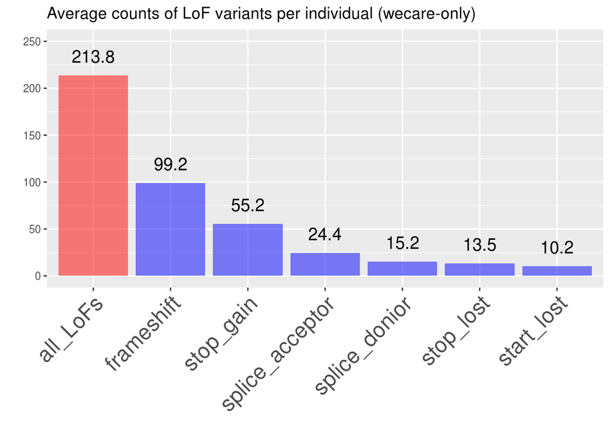

```r
# mean count of alleles per case in wecare
lof_wecare.mx <- genotypes.mx[lof,]
lof_wecare.counts <- apply(lof_wecare.mx, 2, sum, na.rm=TRUE)
lof_wecare.mean <- mean(lof_wecare.counts, na.rm=TRUE) # ~214
rm(lof_wecare.mx, lof_wecare.counts)

# ------- Plot average counts of lof-s per individual ------- #

# Summary table with average numbers of lof-s per individual
lof_summary_counts.df <- as.data.frame(cbind(
  lof_type=c("splice_acceptor", "splice_donior", "stop_gain", "stop_lost", "start_lost", "frameshift", "all_LoFs"),
  lof_count=c(sav_wecare.mean, sdv_wecare.mean, stogv_wecare.mean, stolv_wecare.mean, stalv_wecare.mean, fsv_wecare.mean, lof_wecare.mean)))

lof_summary_counts.df$lof_count <- as.numeric(as.vector(lof_summary_counts.df$lof_count))
lof_summary_counts.df <- lof_summary_counts.df %>% arrange(desc(lof_count))

# Order of levels defines order of bars on the plot
lof_summary_counts.df$lof_type <- factor(lof_summary_counts.df$lof_type,
  levels=c("all_LoFs", "frameshift", "stop_gain", "splice_acceptor", "splice_donior", "stop_lost", "start_lost"))

# Plot
ggplot(lof_summary_counts.df, aes(lof_type, lof_count)) +
  geom_bar(stat="identity", fill=c("red",rep("blue",6)), alpha=0.5) +
  geom_text(aes(label=round(lof_count,1)), vjust=-1, size=5)+
  labs(x = "", y = "") +
  ylim(0,250) +
  theme(axis.text.x = element_text(hjust=1, size=18, angle=45)) +
  ggtitle("Average counts of LoF variants per individual (wecare-only)")
```

```r
# Clean-up
rm(splice_acceptor_variant, splice_donor_variant, stop_gain, frameshift_variant, stop_lost,
   start_lost, sav_wecare.mean, sdv_wecare.mean, stogv_wecare.mean, stolv_wecare.mean,
   stalv_wecare.mean, fsv_wecare.mean, lof_summary_counts.df)
```

## make_missense_index

Selecting missense variants which are both: [ deleterious by SIFT ] AND [ probably_damaging by PolyPhen ]

```r
missense_all <- grepl( "missense_variant", variants.df$Consequence)
sum(missense_all) # 86,342
```

```
## [1] 86342
```

```r
summary(variants.df$SIFT_call)
```

```
##                deleterious deleterious_low_confidence
##                      29196                       2755
##                  tolerated   tolerated_low_confidence
##                      42850                       4309
##                       NA's
##                     158148
```

```r
# note many NAs; these are when SIFT is irrelevant (e.g. non-coding)?
deleterious <- variants.df$SIFT_call == "deleterious"
summary(deleterious)
```

```
##    Mode   FALSE    TRUE    NA's
## logical   49914   29196  158148
```

```r
FALSE -> deleterious[is.na(deleterious)]
summary(deleterious) # 29,196
```

```
##    Mode   FALSE    TRUE
## logical  208062   29196
```

```r
summary(variants.df$PolyPhen_call)
```

```
##            benign possibly_damaging probably_damaging           unknown
##             50878             13534             18918              2703
##              NA's
##            151225
```

```r
# note many NAs; these are when PolyPhen is irrelevant (e.g. non-coding)?
probably_damaging <- variants.df$PolyPhen_call == "probably_damaging"
summary(probably_damaging)
```

```
##    Mode   FALSE    TRUE    NA's
## logical   67115   18918  151225
```

```r
FALSE -> probably_damaging[is.na(probably_damaging)]
summary(probably_damaging) # 18,918
```

```
##    Mode   FALSE    TRUE
## logical  218340   18918
```

```r
missense <- deleterious & probably_damaging
sum(missense) # 13,752
```

```
## [1] 13752
```

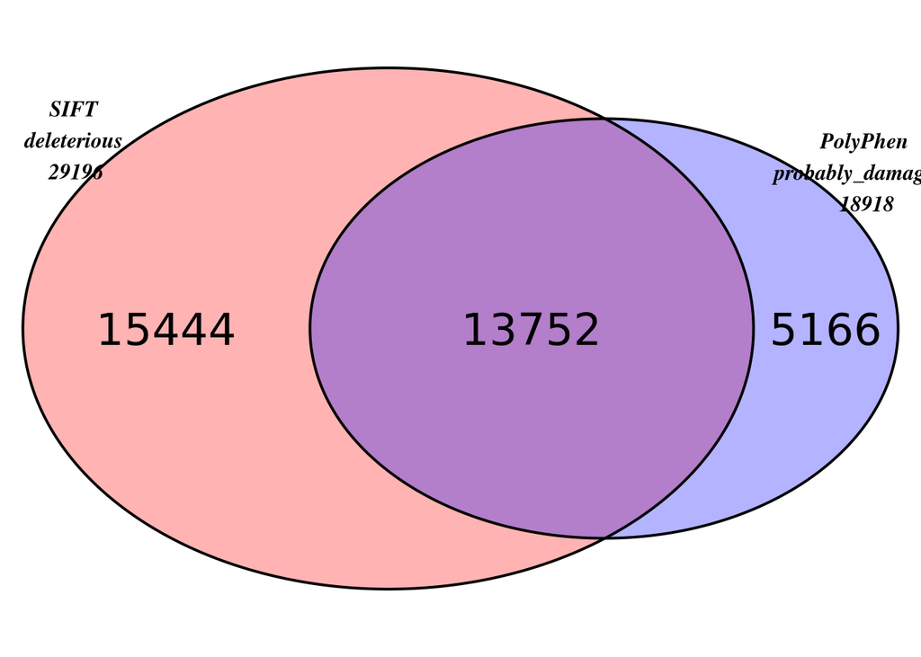

```
## (polygon[GRID.polygon.44], polygon[GRID.polygon.45], polygon[GRID.polygon.46], polygon[GRID.polygon.47], text[GRID.text.48], text[GRID.text.49], text[GRID.text.50], text[GRID.text.51], text[GRID.text.52])
```

```r
# Plot venn diagram of selected variants by types
grid.newpage()
draw.pairwise.venn(
  area1=sum(deleterious),
  area2=sum(probably_damaging),
  cross.area=sum(missense),
  category=c(
    paste("SIFT\ndeleterious\n", sum(deleterious)),
    paste("PolyPhen\nprobably_damaging\n", sum(probably_damaging))),
  fill=c("red", "blue"),
  alpha = c(0.3, 0.3),
  cex=2, cat.fontface=4, fontfamily=3)
```

```r
# mean count of missenses per case in wecare
missense_wecare.mx <- genotypes.mx[missense,]
missense_wecare.counts <- apply(missense_wecare.mx, 2, sum, na.rm=TRUE)
missense_wecare.mean <- mean(missense_wecare.counts, na.rm=TRUE)
missense_wecare.mean # ~374
```

```
## [1] 374.4456
```

```r
# Clean-up
rm(missense_all, deleterious, probably_damaging, missense_wecare.mx, missense_wecare.counts)
```

## make_clinsig_index

ClinSig version as reported by Ensembl v87-grch37_vep_cache (Jan2017, VEP script)  
ClinVar may become a better variant-annotation database, which may be used in future.

Selected clinsig variants  
pathogenic/likely_pathogenic, risk_factor, association, protective, drug_response

Excluded clinsig variants  
likely_benign/benign

All *CLIN_SIG* annotations found in the file:  
likely_benign/benign, pathogenic/likely_pathogenic,  
risk_factor, association, protective, drug_response,  
not_provided, uncertain_significance, other

Note that sums would not need na.rm=TRUE

```r
# --- likely_pathogenic and pathogenic (pat)  --- #

pathogenic_variant <- grepl( "pathogenic", variants.df$CLIN_SIG)
summary(pathogenic_variant) # 851
```

```
##    Mode   FALSE    TRUE
## logical  236407     851
```

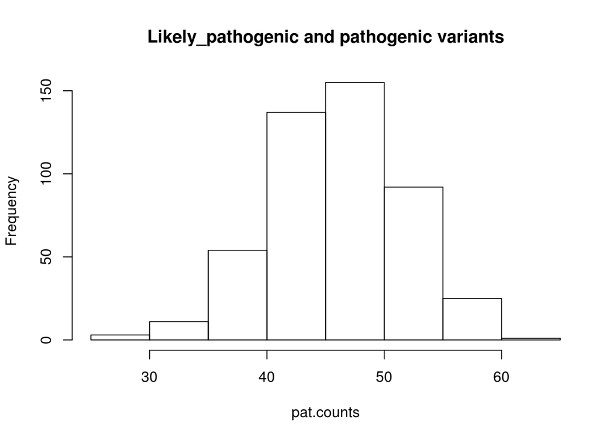

```r
# mean count of alleles per case
pat.mx <- genotypes.mx[pathogenic_variant,]
pat.counts <- apply(pat.mx, 2, sum, na.rm=TRUE)
hist(pat.counts, main="Likely_pathogenic and pathogenic variants")
```

```r
pat.mean <- mean(pat.counts, na.rm=TRUE)
pat.mean # ~46
```

```
## [1] 46.4477
```

```r
rm(pat.mx, pat.counts)

# --- risk_factor (rsf)  --- #

risk_factor_variant <- grepl( "risk_factor", variants.df$CLIN_SIG)
summary(risk_factor_variant) # 179
```

```
##    Mode   FALSE    TRUE
## logical  237079     179
```

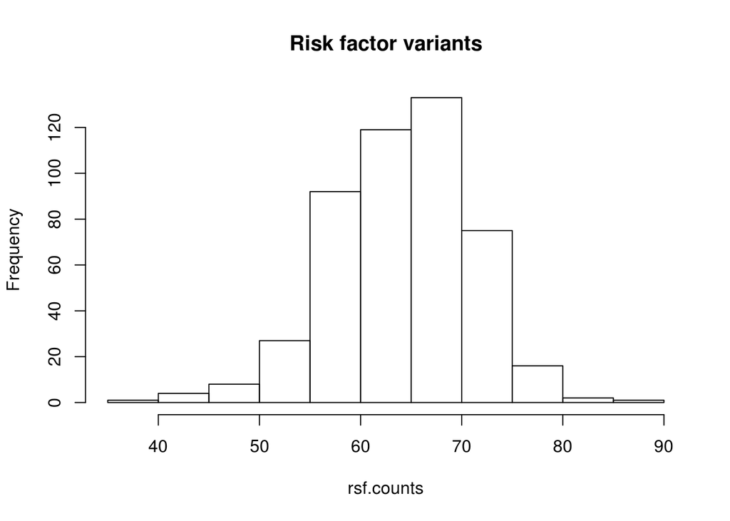

```r
# mean count of alleles per case
rsf.mx <- genotypes.mx[risk_factor_variant,]
rsf.counts <- apply(rsf.mx, 2, sum, na.rm=TRUE)
hist(rsf.counts, main="Risk factor variants")
```

```r
rsf.mean <- mean(rsf.counts, na.rm=TRUE)
rsf.mean # ~65
```

```
## [1] 64.58996
```

```r
rm(rsf.mx, rsf.counts)

# --- association (asc) --- #

association_variant <- grepl( "association", variants.df$CLIN_SIG)
summary(association_variant) # 28
```

```
##    Mode   FALSE    TRUE
## logical  237230      28
```

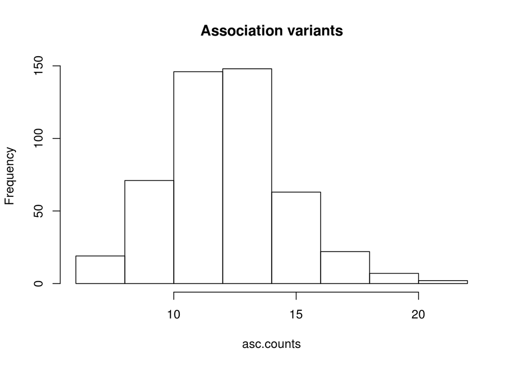

```r
# mean count of alleles per case
asc.mx <- genotypes.mx[association_variant,]
asc.counts <- apply(asc.mx, 2, sum, na.rm=TRUE)
hist(asc.counts, main="Association variants")
```

```r
asc.mean <- mean(asc.counts, na.rm=TRUE)
asc.mean # ~13
```

```
## [1] 12.59833
```

```r
rm(asc.mx, asc.counts)

# --- protective (prt) --- #

protective_variant <- grepl( "protective", variants.df$CLIN_SIG)
summary(protective_variant) # 31
```

```
##    Mode   FALSE    TRUE
## logical  237227      31
```

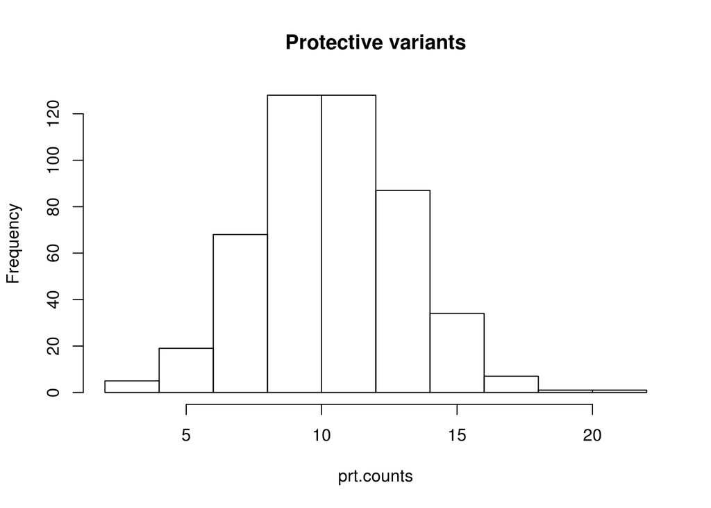

```r
# mean count of alleles per case
prt.mx <- genotypes.mx[protective_variant,]
prt.counts <- apply(prt.mx, 2, sum, na.rm=TRUE)
hist(prt.counts, main = "Protective variants")
```

```r
prt.mean <- mean(prt.counts, na.rm=TRUE)
prt.mean # ~11
```

```
## [1] 10.87238
```

```r
rm(prt.mx, prt.counts)

# --- drug_response (drs) --- #

drug_response_variant <- grepl( "drug_response", variants.df$CLIN_SIG)
summary(drug_response_variant) # 58
```

```
##    Mode   FALSE    TRUE
## logical  237200      58
```

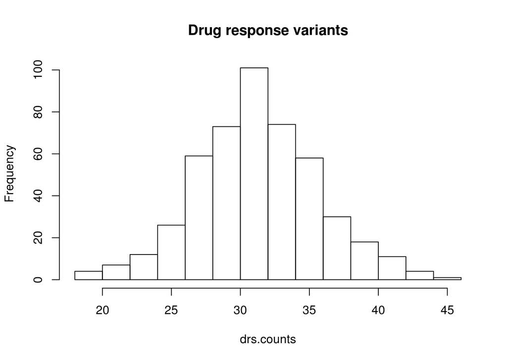

```r
# mean count of alleles per case
drs.mx <- genotypes.mx[drug_response_variant,]
drs.counts <- apply(drs.mx, 2, sum, na.rm=TRUE)
hist(drs.counts, main="Drug response variants")
```

```r
drs.mean <- mean(drs.counts, na.rm=TRUE)
drs.mean # ~32
```

```
## [1] 31.74268
```

```r
rm(drs.mx, drs.counts)

# --- Make toal index of selected clinsig --- #
selected_clinsig <- pathogenic_variant | risk_factor_variant | association_variant | protective_variant | drug_response_variant
summary(selected_clinsig) # 1,091
```

```
##    Mode   FALSE    TRUE
## logical  236167    1091
```

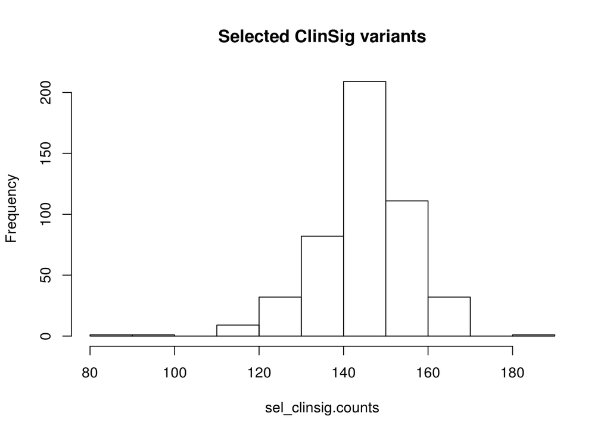

```r
# mean count of alleles per case
sel_clinsig.mx <- genotypes.mx[selected_clinsig,]
sel_clinsig.counts <- apply(sel_clinsig.mx, 2, sum, na.rm=TRUE)
hist(sel_clinsig.counts, main="Selected ClinSig variants")
```

```r
sel_clinsig.mean <- mean(sel_clinsig.counts, na.rm=TRUE)
sel_clinsig.mean # ~145
```

```
## [1] 145.3619
```

```r
rm(sel_clinsig.mx, sel_clinsig.counts)

# --- Make toal index of excluded clinsig --- #

excluded_clinsig <- grepl( "benign", variants.df$CLIN_SIG)
summary(excluded_clinsig) # 11,709
```

```
##    Mode   FALSE    TRUE
## logical  225549   11709
```

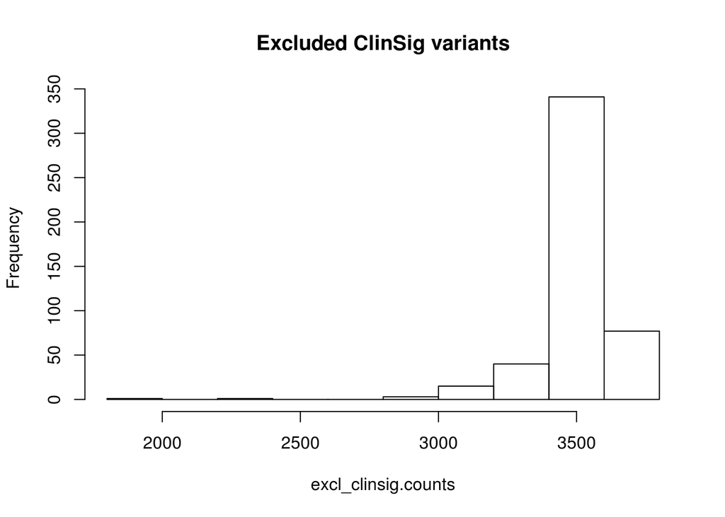

```r
# mean count of alleles per case
excl_clinsig.mx <- genotypes.mx[excluded_clinsig,]
excl_clinsig.counts <- apply(excl_clinsig.mx, 2, sum, na.rm=TRUE)
hist(excl_clinsig.counts, main="Excluded ClinSig variants")
```

```r
excl_clinsig.mean <- mean(excl_clinsig.counts, na.rm=TRUE)
excl_clinsig.mean # ~3,493
```

```
## [1] 3492.948
```

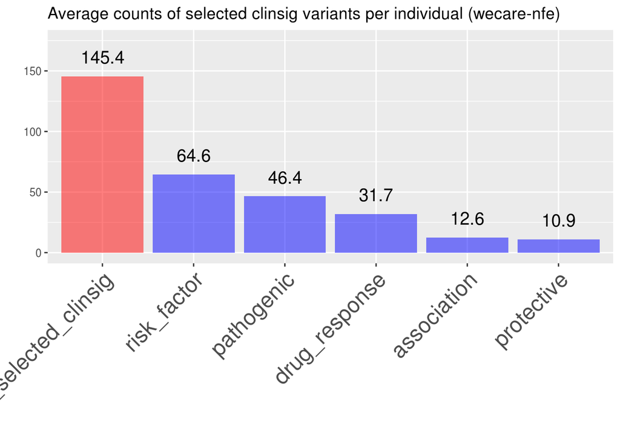

```r
rm(excl_clinsig.mx, excl_clinsig.counts)

# ------- Plot average counts of clinsig variants per individual ------- #

# Summary table with average numbers of clinsig variants per individual
clinsig_counts.df <- as.data.frame(cbind(
  clinsig_type=c("pathogenic", "risk_factor", "association", "protective", "drug_response", "All_selected_clinsig"),
  clinsig_count=c(pat.mean, rsf.mean, asc.mean, prt.mean, drs.mean, sel_clinsig.mean)))

# Convert to vector and sort
clinsig_counts.df$clinsig_count <- as.numeric(as.vector(clinsig_counts.df$clinsig_count))
clinsig_counts.df <- clinsig_counts.df %>% arrange(desc(clinsig_count))

# Order of levels defines order of bars on the plot
clinsig_counts.df$clinsig_type <- factor(clinsig_counts.df$clinsig_type,
  levels=c("All_selected_clinsig", "risk_factor", "pathogenic", "drug_response", "association", "protective"))

# Plot
ggplot(clinsig_counts.df, aes(clinsig_type, clinsig_count)) +
  geom_bar(stat="identity", fill=c("red",rep("blue",5)), alpha=0.5) +
  geom_text(aes(label=round(clinsig_count,1)), vjust=-1, size=5) +
  labs(x = "", y = "") +
  ylim(0,175) +
  theme(axis.text.x = element_text(hjust=1, size=18, angle=45)) +
  ggtitle("Average counts of selected clinsig variants per individual (wecare-nfe)")
```

```r
# --- Count inconsistent clinsig annotations --- #
sum(selected_clinsig & excluded_clinsig)
```

```
## [1] 218
```

```r
# Clean-up
rm(pathogenic_variant, risk_factor_variant, association_variant, protective_variant, drug_response_variant,
  clinsig_counts.df, pat.mean, rsf.mean, asc.mean, prt.mean, drs.mean)
```

## explore_selected_types_per_individual_and_per_variantset

```r
# Count combinations of selectred categories
lof_missense <- lof & missense
clinsig_missense <- selected_clinsig & missense
lof_clinsig <- lof & selected_clinsig
lof_clinsig_missense <- lof_clinsig & missense

summary(lof_missense) # 8
```

```
##    Mode   FALSE    TRUE
## logical  237250       8
```

```r
summary(clinsig_missense) # 278
```

```
##    Mode   FALSE    TRUE
## logical  236980     278
```

```r
summary(lof_clinsig) # 115
```

```
##    Mode   FALSE    TRUE
## logical  237143     115
```

```r
summary(lof_clinsig_missense) # 0
```

```
##    Mode   FALSE
## logical  237258
```

```r
selected_variants <- lof | selected_clinsig | missense

summary(selected_variants) # 18,390
```

```
##    Mode   FALSE    TRUE
## logical  218868   18390
```

```r
# Exclude benign clinsigs

summary(selected_variants & excluded_clinsig) # 533
```

```
##    Mode   FALSE    TRUE
## logical  236725     533
```

```r
selected_variants <- selected_variants & ! excluded_clinsig
summary(selected_variants) # 17,857
```

```
##    Mode   FALSE    TRUE
## logical  219401   17857
```

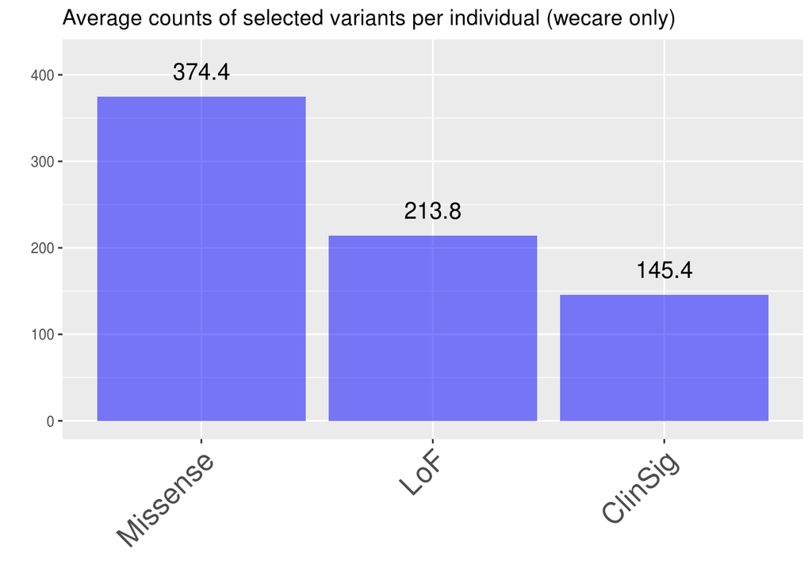

```r
# --- Plot mean counts of variant types per individual --- #

# Summary table with average numbers of protein-affecting per individual
summary_counts.df <- as.data.frame(cbind(
  type=c("Missense", "LoF", "ClinSig"),
  count=c(missense_wecare.mean, lof_wecare.mean, sel_clinsig.mean)))

# Convert numbers to numeric vector
summary_counts.df$count <- as.numeric(as.vector(summary_counts.df$count))

# Order of levels defines order of bars on the plot
summary_counts.df$type <- factor(summary_counts.df$type,
  levels=c("Missense", "LoF", "ClinSig"))

# Plot bar diagramm of avg. count of selected types per individual
ggplot(summary_counts.df, aes(type, count)) +
  geom_bar(stat="identity", fill="blue", alpha=0.5) +
  geom_text(aes(label=round(count,1)), vjust=-1, size=5)+
  ylim(0, 420) +
  labs(x = "", y = "") +
  theme(axis.text.x = element_text(hjust=1, size=18, angle=45)) +
  ggtitle("Average counts of selected variants per individual (wecare only)")
```

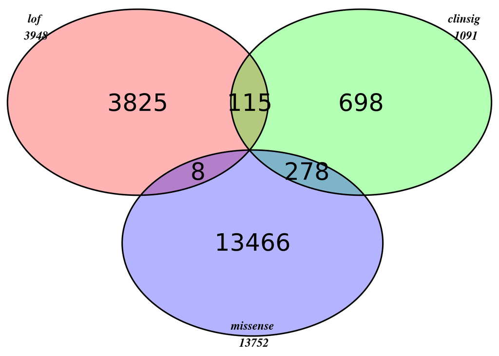

```
## (polygon[GRID.polygon.139], polygon[GRID.polygon.140], polygon[GRID.polygon.141], polygon[GRID.polygon.142], polygon[GRID.polygon.143], polygon[GRID.polygon.144], text[GRID.text.145], text[GRID.text.146], text[GRID.text.147], text[GRID.text.148], text[GRID.text.149], text[GRID.text.150], text[GRI…
```

```r
# Plot venn diagram of selected variants by types
grid.newpage()
draw.triple.venn(
  area1=sum(lof),
  area2=sum(selected_clinsig),
  area3=sum(missense),
  n12=sum(lof_clinsig),
  n23=sum(clinsig_missense),
  n13=sum(lof_missense),
  n123=sum(lof_clinsig_missense),
  category=c(
    paste("lof\n", sum(lof)),
    paste("clinsig\n", sum(selected_clinsig)),
    paste("missense\n", sum(missense))),
  fill = c("red", "green", "blue"),
  alpha = c(0.3, 0.3, 0.3),
  cex=2, cat.fontface=4, fontfamily=3)
```

```r
rm(missense_wecare.mean, lof_wecare.mean, sel_clinsig.mean, excl_clinsig.mean, lof, selected_clinsig,
   excluded_clinsig, missense, clinsig_missense, lof_clinsig, lof_missense, lof_clinsig_missense,
   summary_counts.df)
```

# keep_selected_variants_only

237,258 -> 17,857

```r
sum(selected_variants) # 17,857
```

```
## [1] 17857
```

```r
variants.df <- variants.df[selected_variants,]
kgen.df <- kgen.df[selected_variants,]
exac.df <- exac.df[selected_variants,]
genotypes.mx <- genotypes.mx[selected_variants,]


dim(variants.df)
```

```
## [1] 17857    45
```

```r
dim(kgen.df)
```

```
## [1] 17857     9
```

```r
dim(exac.df)
```

```
## [1] 17857    48
```

```r
dim(genotypes.mx)
```

```
## [1] 17857   478
```

```r
# Clean-up
rm(selected_variants)
```

# — further explore selected variants —

This is done here for interim exploration only.  
It will be re-calculated after the variants filtering (AF < 0.05)

## count_selected_multiallelic_varaints

```r
summary(variants.df$Multiallelic) # 394
```

```
##    Mode   FALSE    TRUE
## logical   17463     394
```

## explore_AFs_in_selected_variants

Most of selected variants are rare (median ~0.1%)  
A small number of retained common variants (AF>5%) will be excluded later,  
also the weihgting will further prioritise rare variants amongst the remaining ones.

```r
mean(variants.df$af_all) # ~1.8%
```

```
## [1] 0.0182979
```

```r
median(variants.df$af_all) # ~0.1%
```

```
## [1] 0.001077586
```

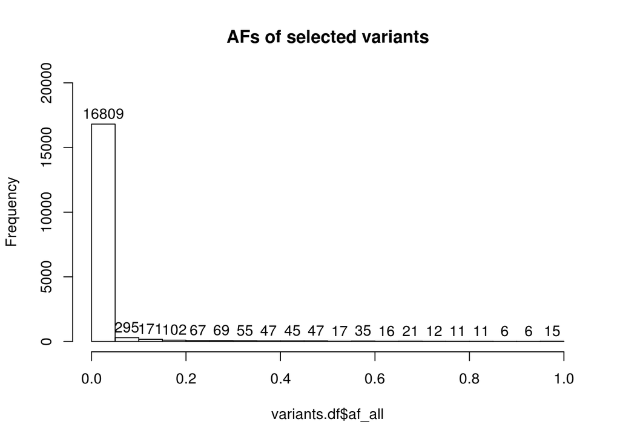

```r
hist(variants.df$af_all, main="AFs of selected variants", labels = TRUE, ylim=c(0,20000))
```

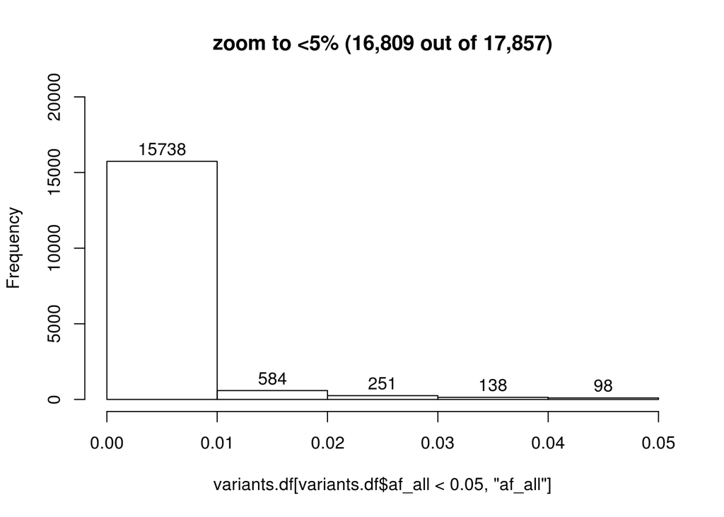

```r
hist(variants.df[variants.df$af_all<0.05,"af_all"],
     ylim=c(0,20000), labels = TRUE, main="zoom to <5% (16,809 out of 17,857)", breaks=5)
```

## explore_variants_counts_per_gene

```r
# Get number of genes
length(unique(variants.df$SYMBOL)) # 8,936
```

```
## [1] 8936
```

```r
# Look at the top genes with high counts of variants
x <- sort(table(as.vector(variants.df$SYMBOL)), decreasing = TRUE)
x[1:200]
```

```
##
##    DNAH3    DNAH7   PKD1L2  PKHD1L1    ABCA4   MYO18B   COL6A6    DUOX2
##       25       25       19       16       15       15       14       14
##    TRPM1     CUBN   DNAH14   IGSF10   MT-CYB  PDE4DIP      ATM   CCDC66
##       14       13       13       13       13       13       12       12
##    LAMA1     LRBA     MUC4     POLG     POLQ     VWA8    C2CD3    DCHS2
##       12       12       12       12       12       12       11       11
##    ECT2L     NOD2   PIEZO1     PLB1   PRUNE2    PTPRQ   ZNF568    ABCC2
##       11       11       11       11       11       11       11       10
##    AMPD1  CCDC141    CES5A    CHEK2 FAM160A1   FER1L6      FN1    LRRC9
##       10       10       10       10       10       10       10       10
##    MYO7A    MYOM2     NID2    SPTA1     SPTB    A2ML1    ATP7B  COL28A1
##       10       10       10       10       10        9        9        9
##    CSMD3   DNAH12   DNASE1      EPX   GPR113    LAMA2    LAMB4    MKI67
##        9        9        9        9        9        9        9        9
##      MPO    MYH13     MYH4     MYOF    NLRP5    PKHD1    POMT1   SLC5A4
##        9        9        9        9        9        9        9        9
##    STAB2       TG      TNC     VWDE   ZNF106    ABCB5   ABCC11      ACE
##        9        9        9        9        9        8        8        8
## ADAMTSL1    ALPK2     ANK1     ASPM     ATIC       C9   CCHCR1     CCR5
##        8        8        8        8        8        8        8        8
##    CD109   CELSR2    DNHD1     DPYD  EFCAB13    INADL KIAA1217    KRT36
##        8        8        8        8        8        8        8        8
##    KRT75    LAMB2      LPA    LRRK1    LRRK2    MYH14    MYH15    MYO1A
##        8        8        8        8        8        8        8        8
##    MYO7B     NAV2     PCK2   PTPN13     SETX       SI   SPAG17     TEP1
##        8        8        8        8        8        8        8        8
##     TPTE    USP45     UTRN    WDR41      XDH   ZNF268    ABCA8 ADAMTS14
##        8        8        8        8        8        8        7        7
##    AGBL1     ANO2  ATP13A5      BLK   CAPN13  CCDC136   CEP192     CFTR
##        7        7        7        7        7        7        7        7
##   CLTCL1    CNTLN     COBL  COL15A1      CR2  CTTNBP2    DAAM2    DNAH6
##        7        7        7        7        7        7        7        7
##   EGFLAM     ELP2    EPB41   ERV3-1     EXO1       F5  FAM186A    FHAD1
##        7        7        7        7        7        7        7        7
##     FMO2   FRMPD1   GPRC6A   IQGAP2    ITIH1 KIAA0556 KIAA1551    LAMC2
##        7        7        7        7        7        7        7        7
##    LAMC3   MALRD1   MCM3AP  MICALCL     MPDZ   MROH2B    MYO5C     NRAP
##        7        7        7        7        7        7        7        7
##    NRDE2     OCA2    OGDHL    P2RX5    PADI4      PAH   PDCD11    PDIA2
##        7        7        7        7        7        7        7        7
##     PHKB   PKD1L1   PLA2R1    PTPRB      PZP     ROS1   SCUBE2  SLC10A2
##        7        7        7        7        7        7        7        7
##   SLC3A1   SLC5A9    SPEF2    SSFA2  TBC1D17    TEX15     TGM4 TIMELESS
##        7        7        7        7        7        7        7        7
##     TLN2     TMC8  TMPRSS7  TRAPPC9    TTLL6  TUBGCP6    UGGT2     ULK4
##        7        7        7        7        7        7        7        7
##   UMODL1   UNC45B    UTP20    WDR27     WDR3   ZNF226   ZNF528      A2M
##        7        7        7        7        7        7        7        6
##    ABCA3   ABCC12   ACAD10    ACOXL   AKAP11  ALDH1B1     ALLC    ALPK1
##        6        6        6        6        6        6        6        6
```

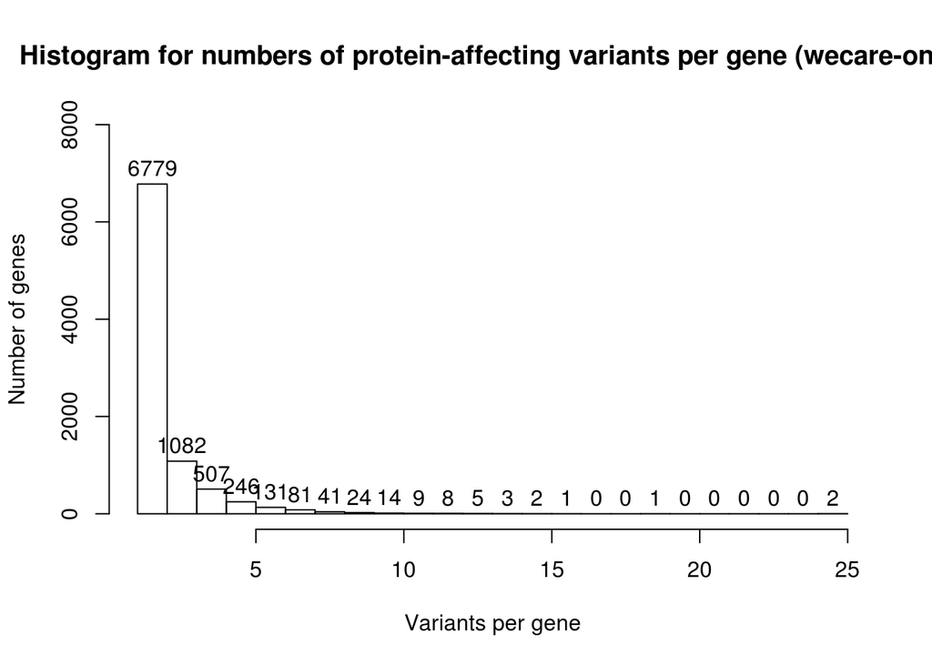

```r
# Table for histogram of numbers of protein-affecting variants per gene
# (not sure whether group_by preserves the order of genes etc,
# but this is not important here)
y <- variants.df %>% group_by(SYMBOL) %>% summarise(n())
"vars_count" -> colnames(y)[2]

# Plot the histogram
hist(y$vars_count, main="Histogram for numbers of protein-affecting variants per gene (wecare-only)", xlab="Variants per gene", ylab="Number of genes", ylim=c(0,8000), breaks=25, labels = TRUE)
```

```r
# Mean number of variants per gene
mean(y$vars_count) # ~2.0
```

```
## [1] 1.998321
```

```r
# Clean-up
rm(x,y)
```

## invert_and_explore_inv_aggr_alt_counts_per_gene

For variants with **total** AF>0.5 MACs are calculated after genotypes inversion.  
The inversion is done here for exploration and crude counts only.  
The inversion of genotypes for analysis is done within SKAT later.

```r
# Get list of genes
genes <- unique(as.character(as.vector(variants.df$SYMBOL)))
length(genes)
```

```
## [1] 8936
```

```r
# Make empty matrix for the inverted gene-aggregated data
genes_inv_aggr_data.mx <- matrix(ncol=ncol(genotypes.mx),nrow=0)
colnames(genes_inv_aggr_data.mx) <- colnames(genotypes.mx)

# Make matrix for the inverted gene-aggregated variants' counts
genes_inv_aggr_info.mx <- matrix(ncol=2, nrow=length(genes))
genes -> genes_inv_aggr_info.mx[,1]
genes -> rownames(genes_inv_aggr_info.mx)
colnames(genes_inv_aggr_info.mx) <- c("gene", "num_vars")

# Invert genotypes with total AF > 0.5
genotypes_inv.mx <- genotypes.mx
for(var in 1:nrow(variants.df)){

  if(variants.df[var,"af_all"] > 0.5){
    genotype <- genotypes.mx[var,]
    inv_genotype <- genotype
    0 -> inv_genotype[genotype == 2]
    2 -> inv_genotype[genotype == 0]
    genotypes_inv.mx[var,] <- inv_genotype
    rm(genotype, inv_genotype)
  }
}

# Calculate inverted gene-aggregated variants' counts
for(gene in genes){

  # Get the gene's variants
  vars <- variants.df$SYMBOL == gene

  # Record the number of variants
  num_vars <- sum(vars)
  num_vars -> genes_inv_aggr_info.mx[gene,"num_vars"]

  # For single-variant genes
  if(num_vars==1){

    # Nothing to aggregate
    counts <- genotypes_inv.mx[vars,] # vector, preserves NA
    0 -> counts[is.na(counts)] # equivalent to na.rm=TRUE below

  # For genes with multiple varians
  }else{

    # Sum alleles in the variants
    counts <- apply(genotypes_inv.mx[vars,], 2, sum, na.rm=TRUE)

  }

  # Add result to output table
  genes_inv_aggr_data.mx <- rbind(genes_inv_aggr_data.mx, counts)

  # Clean-up
  rm(vars, num_vars, counts)

}

# Check result
# (atrix with aggregated inverted counts per gene per case)
dim(genes_inv_aggr_data.mx)
```

```
## [1] 8936  478
```

```r
genes -> rownames(genes_inv_aggr_data.mx)
genes_inv_aggr_data.mx[1:5,1:5]
```

```
##        P1_A01 P1_A02 P1_A03 P1_A04 P1_A05
## NOC2L       0      0      0      0      0
## KLHL17      0      0      0      0      0
## AGRN        0      0      0      0      0
## TTLL10      0      0      0      0      0
## CPSF3L      0      0      0      0      0
```

```r
# Aggregated counts per gene
aggr_inv_AC <- apply(genes_inv_aggr_data.mx, 1, sum,na.rm=TRUE)

# Data frame with num_var-s and aggregated MACs for all genes
genes_inv_aggr_info.df <- as.data.frame(cbind(genes_inv_aggr_info.mx, aggr_inv_AC))
genes_inv_aggr_info.df$gene <- as.vector(genes_inv_aggr_info.df$gene)
genes_inv_aggr_info.df$num_vars <- as.numeric(as.vector(genes_inv_aggr_info.df$num_vars))
genes_inv_aggr_info.df$aggr_inv_AC <- as.numeric(as.vector(genes_inv_aggr_info.df$aggr_inv_AC))

# Explore result
str(genes_inv_aggr_info.df)
```

```
## 'data.frame':    8936 obs. of  3 variables:
##  $ gene       : chr  "NOC2L" "KLHL17" "AGRN" "TTLL10" ...
##  $ num_vars   : num  3 2 2 1 1 1 1 2 1 1 ...
##  $ aggr_inv_AC: num  4 2 2 2 1 1 41 3 1 1 ...
```

```r
genes_inv_aggr_info.df[1:5,]
```

```
##          gene num_vars aggr_inv_AC
## NOC2L   NOC2L        3           4
## KLHL17 KLHL17        2           2
## AGRN     AGRN        2           2
## TTLL10 TTLL10        1           2
## CPSF3L CPSF3L        1           1
```

```r
genes_inv_aggr_info.df[genes_inv_aggr_info.df$gene %in% c("ATM", "CHEK2"),]
```

```
##        gene num_vars aggr_inv_AC
## ATM     ATM       12          15
## CHEK2 CHEK2       10          19
```

```r
# Genes with frequent protein-affecting alt alleles
x <- aggr_inv_AC[order(-aggr_inv_AC)]
mean(x) # ~28
```

```
## [1] 27.65387
```

```r
median(x) # 2
```

```
## [1] 2
```

```r
x[1:100]
```

```
##     CELA1    PKD1L2   TAS2R38      NAT2    MS4A14    OR11H6      SRA1
##      1401      1337      1272      1110       943       932       890
##    OR11H7     GSDMB  C1orf222     MUC19  KIAA0040      RHBG    PRSS48
##       879       862       857       856       855       843       815
##     OR2J1     ADRB2     SMYD4     OR1B1  KIAA0753    PTCHD3    CCHCR1
##       811       720       712       701       698       684       649
## KRTAP10-1      IDO2    CCDC66  C11orf40    ZNF568     EXPH5     ACOT4
##       648       634       629       622       622       621       621
##     KRT72       PZP   EFCAB13    OR51I2  IGLV3-22     OR4X1    OR13C5
##       613       609       608       603       592       591       576
##     STOX1       CFH  SIGLEC12  IGLV3-12    ERV3-1   DEFB126    PKD1L1
##       574       573       560       545       544       539       532
##   ANKRD33    SPAG17       PPL     TPCN2    GPRC6A    GPRIN1     ALPK2
##       532       529       522       514       504       498       497
##     OR1I1     KRT77     OR2G2      MUC4    OR10X1  IGHV3-48   FAM186A
##       496       491       488       488       486       486       481
## SERPINB11      CHIA   ATP13A5     GSDMC    OR51B6    CHMP4A    CX3CR1
##       477       474       473       473       473       473       471
##     SUMO4     APOL4    MROH2A     KLKB1     PLCL1    ZNF404      IL24
##       469       467       466       466       464       464       463
##    ZNF880     DNAH3    NIPAL2    MYO18A  TRBV10-1    CLECL1     NLRP1
##       463       462       461       461       460       459       459
## KRTAP13-2   PGPEP1L   C5orf20   MAGEB16     MOB3C       CD5    OR10D3
##       459       458       457       456       455       455       454
##    CYP2A7  SLC22A10      LRMP   TMEM244     PLBD1    KCNMB3     OR6S1
##       454       452       452       450       450       446       444
##    FCGR2A     P2RX7     HTR3D     DCHS2     CCND1     ABCB1  TIMELESS
##       442       442       441       439       437       436       436
##     OR2J2      FMO2
##       435       433
```

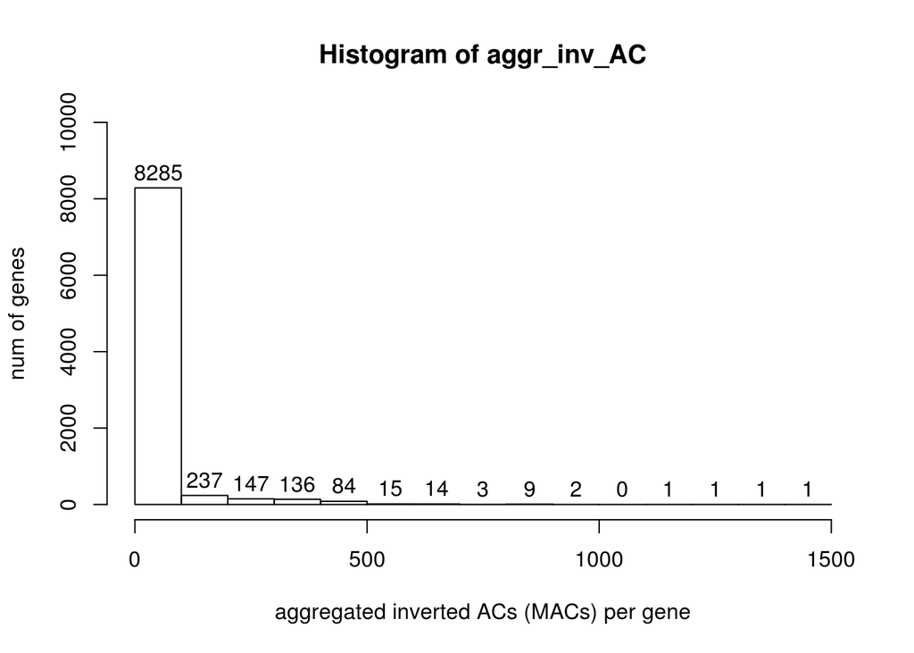

```r
# Histograms of aggregated MACs
hist(aggr_inv_AC, labels = TRUE, ylim=c(0,10000),
     xlab="aggregated inverted ACs (MACs) per gene", ylab="num of genes")
```

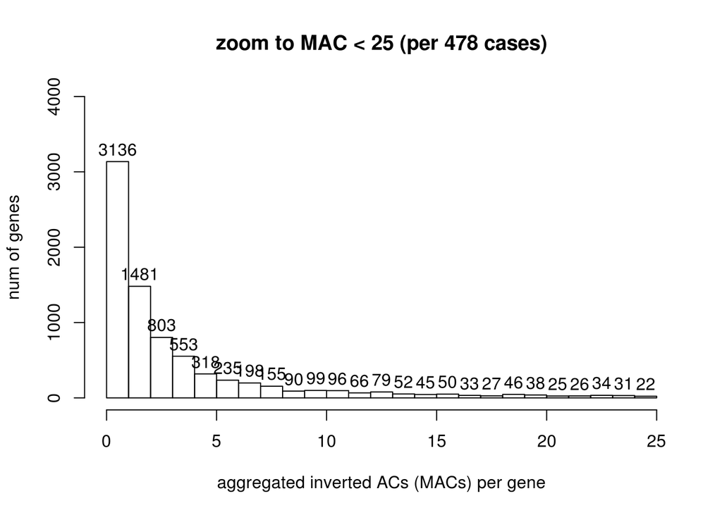

```
##  [1] 3136 1481  803  553  318  235  198  155   90   99   96   66   79   52
## [15]   45   50   33   27   46   38   25   26   34   31   22
```

```r
hist(aggr_inv_AC[aggr_inv_AC<26], breaks=c(0:25),
     labels = TRUE, ylim=c(0,4000), main="zoom to MAC < 25 (per 478 cases)",
     xlab="aggregated inverted ACs (MACs) per gene", ylab="num of genes")$counts
```

```r
# Counts < 10 (< 1% aggregated MAF) - too rare for analysis ??
sum(aggr_inv_AC < 10) # 6,969
```

```
## [1] 6969
```

```r
# Genes that may be analysed
sum(aggr_inv_AC >= 10) # 1,967 (ATM=15; CHEK2=19)
```

```
## [1] 1967
```

```r
# Aggregated MACs > 100 (~ >10% aggregated MAF) - too common for being pathogenic ??
sum(aggr_inv_AC > 100) # 651
```

```
## [1] 651
```

```r
# Weighting and filtering will take care of the "common" variants in multi-variant genes

# Clean-up
rm(genes_inv_aggr_data.mx, genes_inv_aggr_info.mx, genes_inv_aggr_info.df,
  genes, gene, aggr_inv_AC, var, x)
```

# data_summary

```r
dim(genotypes.mx)
```

```
## [1] 17857   478
```

```r
class(genotypes.mx)
```

```
## [1] "matrix"
```

```r
genotypes.mx[c(1:5,591),1:5]
```

```
##              P1_A01 P1_A02 P1_A03 P1_A04 P1_A05
## Var000000026      0     NA      0      0      0
## Var000000029      0      0      0      0      0
## Var000000031      0      0      0      0      0
## Var000000053      0      0      0      0     NA
## Var000000064      0      0      0      0     NA
## Var000011561      0      2     NA      2      2
```

```r
dim(genotypes_inv.mx)
```

```
## [1] 17857   478
```

```r
class(genotypes_inv.mx)
```

```
## [1] "matrix"
```

```r
genotypes_inv.mx[c(1:5,591),1:5]
```

```
##              P1_A01 P1_A02 P1_A03 P1_A04 P1_A05
## Var000000026      0     NA      0      0      0
## Var000000029      0      0      0      0      0
## Var000000031      0      0      0      0      0
## Var000000053      0      0      0      0     NA
## Var000000064      0      0      0      0     NA
## Var000011561      2      0     NA      0      0
```

```r
dim(kgen.df)
```

```
## [1] 17857     9
```

```r
colnames(kgen.df)
```

```
## [1] "SplitVarID"  "kgen.AC"     "kgen.AN"     "kgen.AF"     "kgen.AFR_AF"
## [6] "kgen.AMR_AF" "kgen.EAS_AF" "kgen.EUR_AF" "kgen.SAS_AF"
```

```r
kgen.df[1:5,1:5]
```

```
##                SplitVarID kgen.AC kgen.AN     kgen.AF kgen.AFR_AF
## Var000000026 Var000000026      NA      NA          NA          NA
## Var000000029 Var000000029       1    5008 0.000199681           0
## Var000000031 Var000000031       1    5008 0.000199681           0
## Var000000053 Var000000053      NA      NA          NA          NA
## Var000000064 Var000000064      NA      NA          NA          NA
```

```r
dim(exac.df)
```

```
## [1] 17857    48
```

```r
colnames(exac.df)
```

```
##  [1] "SplitVarID"              "exac_non_TCGA.AF"
##  [3] "exac_non_TCGA.AC"        "exac_non_TCGA.AN"
##  [5] "exac_non_TCGA.AC_FEMALE" "exac_non_TCGA.AN_FEMALE"
##  [7] "exac_non_TCGA.AC_MALE"   "exac_non_TCGA.AN_MALE"
##  [9] "exac_non_TCGA.AC_Adj"    "exac_non_TCGA.AN_Adj"
## [11] "exac_non_TCGA.AC_Hom"    "exac_non_TCGA.AC_Het"
## [13] "exac_non_TCGA.AC_Hemi"   "exac_non_TCGA.AC_AFR"
## [15] "exac_non_TCGA.AN_AFR"    "exac_non_TCGA.Hom_AFR"
## [17] "exac_non_TCGA.Het_AFR"   "exac_non_TCGA.Hemi_AFR"
## [19] "exac_non_TCGA.AC_AMR"    "exac_non_TCGA.AN_AMR"
## [21] "exac_non_TCGA.Hom_AMR"   "exac_non_TCGA.Het_AMR"
## [23] "exac_non_TCGA.Hemi_AMR"  "exac_non_TCGA.AC_EAS"
## [25] "exac_non_TCGA.AN_EAS"    "exac_non_TCGA.Hom_EAS"
## [27] "exac_non_TCGA.Het_EAS"   "exac_non_TCGA.Hemi_EAS"
## [29] "exac_non_TCGA.AC_FIN"    "exac_non_TCGA.AN_FIN"
## [31] "exac_non_TCGA.Hom_FIN"   "exac_non_TCGA.Het_FIN"
## [33] "exac_non_TCGA.Hemi_FIN"  "exac_non_TCGA.AC_NFE"
## [35] "exac_non_TCGA.AN_NFE"    "exac_non_TCGA.Hom_NFE"
## [37] "exac_non_TCGA.Het_NFE"   "exac_non_TCGA.Hemi_NFE"
## [39] "exac_non_TCGA.AC_SAS"    "exac_non_TCGA.AN_SAS"
## [41] "exac_non_TCGA.Hom_SAS"   "exac_non_TCGA.Het_SAS"
## [43] "exac_non_TCGA.Hemi_SAS"  "exac_non_TCGA.AC_OTH"
## [45] "exac_non_TCGA.AN_OTH"    "exac_non_TCGA.Hom_OTH"
## [47] "exac_non_TCGA.Het_OTH"   "exac_non_TCGA.Hemi_OTH"
```

```r
exac.df[1:5,1:5]
```

```
##                SplitVarID exac_non_TCGA.AF exac_non_TCGA.AC
## Var000000026 Var000000026               NA               NA
## Var000000029 Var000000029        1.506e-04               16
## Var000000031 Var000000031        2.354e-04               25
## Var000000053 Var000000053        1.883e-05                2
## Var000000064 Var000000064        9.416e-06                1
##              exac_non_TCGA.AN exac_non_TCGA.AC_FEMALE
## Var000000026               NA                      NA
## Var000000029           106210                       8
## Var000000031           106210                       4
## Var000000053           106210                       0
## Var000000064           106206                       0
```

```r
dim(variants.df)
```

```
## [1] 17857    45
```

```r
str(variants.df)
```

```
## 'data.frame':    17857 obs. of  45 variables:
##  $ SplitVarID        : Factor w/ 343824 levels "Var000000001",..: 26 29 31 53 64 227 237 300 413 430 ...
##  $ SYMBOL            : Factor w/ 19862 levels "A1BG","A1CF",..: 11149 11149 11149 8665 8665 540 540 18233 3808 6597 ...
##  $ TYPE              : Factor w/ 2 levels "INDEL","SNP": 2 2 2 2 2 2 2 2 2 2 ...
##  $ CHROM             : Factor w/ 25 levels "1","10","11",..: 1 1 1 1 1 1 1 1 1 1 ...
##  $ POS               : int  881871 883883 883946 897287 897792 987173 989899 1132513 1249141 1262635 ...
##  $ REF               : Factor w/ 2142 levels "A","AAAAAAAAAAAAAAAAAAAAAAAG",..: 1044 1575 539 539 539 1575 539 539 1044 1575 ...
##  $ ALT               : Factor w/ 1297 levels "A","AAAAAAAAAAAAACT",..: 1 323 989 989 989 664 989 989 1 1 ...
##  $ ac_raw            : int  1 2 1 1 1 1 1 2 1 1 ...
##  $ af_raw            : num  0.000711 0.001555 0.000774 0.000711 0.000722 ...
##  $ an_raw            : int  1406 1286 1292 1406 1386 1420 1414 1320 1378 1380 ...
##  $ Consequence       : Factor w/ 78 levels "3_prime_UTR_variant",..: 66 28 28 28 66 28 28 28 28 28 ...
##  $ SIFT_call         : Factor w/ 4 levels "deleterious",..: NA 1 1 1 NA 1 1 1 1 1 ...
##  $ SIFT_score        : num  NA 0 0.01 0.04 NA 0 0.02 0.02 0 0 ...
##  $ PolyPhen_call     : Factor w/ 4 levels "benign","possibly_damaging",..: NA 3 3 3 NA 3 3 3 3 3 ...
```

[output cut: 31 more lines]

```r
variants.df[1:5,1:5]
```

```
##                SplitVarID SYMBOL TYPE CHROM    POS
## Var000000026 Var000000026  NOC2L  SNP     1 881871
## Var000000029 Var000000029  NOC2L  SNP     1 883883
## Var000000031 Var000000031  NOC2L  SNP     1 883946
## Var000000053 Var000000053 KLHL17  SNP     1 897287
## Var000000064 Var000000064 KLHL17  SNP     1 897792
```

```r
dim(phenotypes.df)
```

```
## [1] 478  36
```

```r
str(phenotypes.df)
```

```
## 'data.frame':    478 obs. of  36 variables:
##  $ wes_id        : chr  "P1_A01" "P1_A02" "P1_A03" "P1_A04" ...
##  $ gwas_id       : chr  "id203568" "id357807" "id325472" "id304354" ...
##  $ merged_id     : chr  "P1_A01_id203568" "P1_A02_id357807" "P1_A03_id325472" "P1_A04_id304354" ...
##  $ filter        : chr  "pass" "pass" "pass" "pass" ...
##  $ cc            : int  1 1 1 1 1 1 0 1 1 0 ...
##  $ setno         : int  203568 357807 325472 304354 222648 244843 276284 297810 250898 226974 ...
##  $ registry      : Factor w/ 5 levels "de","IA","IR",..: 3 4 2 2 5 4 2 4 4 2 ...
##  $ family_history: int  1 0 1 1 1 1 1 1 1 0 ...
##  $ age_dx        : int  49 35 32 33 44 28 28 38 35 36 ...
##  $ age_ref       : num  58 36 41 34 49 28 32 44 35 38 ...
##  $ rstime        : num  10.17 1.83 9.75 1.59 5.66 ...
##  $ eig1_gwas     : num  -0.00389 -0.00379 -0.01011 -0.01288 -0.01086 ...
##  $ eig2_gwas     : num  0.00266 0.00246 -0.0001 0.00595 0.01157 ...
##  $ eig3_gwas     : num  0.06803 0.05055 -0.00603 0.00747 0.00144 ...
```

[output cut: 22 more lines]

```r
phenotypes.df[1:5,1:5]
```

```
##        wes_id  gwas_id       merged_id filter cc
## P1_A01 P1_A01 id203568 P1_A01_id203568   pass  1
## P1_A02 P1_A02 id357807 P1_A02_id357807   pass  1
## P1_A03 P1_A03 id325472 P1_A03_id325472   pass  1
## P1_A04 P1_A04 id304354 P1_A04_id304354   pass  1
## P1_A05 P1_A05 id222648 P1_A05_id222648   pass  1
```

```r
# Check consistency of rownames and colnames
sum(colnames(genotypes.mx) != rownames(phenotypes.df))
```

```
## [1] 0
```

```r
sum(rownames(genotypes.mx) != rownames(kgen.df))
```

```
## [1] 0
```

```r
sum(rownames(genotypes.mx) != rownames(exac.df))
```

```
## [1] 0
```

```r
sum(rownames(genotypes.mx) != rownames(variants.df))
```

```
## [1] 0
```

# save_data

```r
#base_folder="/analysis/mtgroup_share/users/alexey/wecare_only_08.17"
save.image(paste(base_folder, "results", "r07_filter_by_variant_effect_wecare_only.RData", sep="/"))
```

# final_section

```r
ls()
```

```
## [1] "base_folder"      "exac.df"          "genotypes_inv.mx"
## [4] "genotypes.mx"     "kgen.df"          "phenotypes.df"
## [7] "variants.df"
```

```r
Sys.time()
```

```
## [1] "2017-08-29 19:13:10 BST"
```